# Optimal Treatment Analysis

## Outcome Variable

**Outcome Variable:** ever_wasted

## Predictor Variables

**Intervention Variable:** nrooms

**Adjustment Set:**

- arm
- sex
- W_mage
- meducyrs
- feducyrs
- hhwealth_quart
- hfoodsec
- W_mhtcm
- W_nchldlt5
- W_parity
- impfloor
- impsan
- safeh20
- delta_W_mage
- delta_meducyrs
- delta_feducyrs
- delta_hhwealth_quart
- delta_hfoodsec
- delta_W_mhtcm
- delta_W_nchldlt5
- delta_W_parity
- delta_impfloor
- delta_impsan
- delta_safeh20

## Stratifying Variables

The analysis was stratified on these variable(s):

- agecat
- studyid
- country

## Data Summary

| agecat | studyid | country | nrooms | ever_wasted | n_cell | n |
| --- | --- | --- | --- | --- | --- | --- |
| 0-24 months | ki0047075b-MAL-ED | BANGLADESH | 4+ | 0 | 9 | 242 |
| 0-24 months | ki0047075b-MAL-ED | BANGLADESH | 4+ | 1 | 3 | 242 |
| 0-24 months | ki0047075b-MAL-ED | BANGLADESH | 1 | 0 | 92 | 242 |
| 0-24 months | ki0047075b-MAL-ED | BANGLADESH | 1 | 1 | 60 | 242 |
| 0-24 months | ki0047075b-MAL-ED | BANGLADESH | 2 | 0 | 37 | 242 |
| 0-24 months | ki0047075b-MAL-ED | BANGLADESH | 2 | 1 | 13 | 242 |
| 0-24 months | ki0047075b-MAL-ED | BANGLADESH | 3 | 0 | 20 | 242 |
| 0-24 months | ki0047075b-MAL-ED | BANGLADESH | 3 | 1 | 8 | 242 |
| 0-24 months | ki0047075b-MAL-ED | BRAZIL | 4+ | 0 | 114 | 210 |
| 0-24 months | ki0047075b-MAL-ED | BRAZIL | 4+ | 1 | 13 | 210 |
| 0-24 months | ki0047075b-MAL-ED | BRAZIL | 1 | 0 | 4 | 210 |
| 0-24 months | ki0047075b-MAL-ED | BRAZIL | 1 | 1 | 0 | 210 |
| 0-24 months | ki0047075b-MAL-ED | BRAZIL | 2 | 0 | 18 | 210 |
| 0-24 months | ki0047075b-MAL-ED | BRAZIL | 2 | 1 | 2 | 210 |
| 0-24 months | ki0047075b-MAL-ED | BRAZIL | 3 | 0 | 55 | 210 |
| 0-24 months | ki0047075b-MAL-ED | BRAZIL | 3 | 1 | 4 | 210 |
| 0-24 months | ki0047075b-MAL-ED | INDIA | 4+ | 0 | 16 | 235 |
| 0-24 months | ki0047075b-MAL-ED | INDIA | 4+ | 1 | 9 | 235 |
| 0-24 months | ki0047075b-MAL-ED | INDIA | 1 | 0 | 43 | 235 |
| 0-24 months | ki0047075b-MAL-ED | INDIA | 1 | 1 | 41 | 235 |
| 0-24 months | ki0047075b-MAL-ED | INDIA | 2 | 0 | 38 | 235 |
| 0-24 months | ki0047075b-MAL-ED | INDIA | 2 | 1 | 40 | 235 |
| 0-24 months | ki0047075b-MAL-ED | INDIA | 3 | 0 | 25 | 235 |
| 0-24 months | ki0047075b-MAL-ED | INDIA | 3 | 1 | 23 | 235 |
| 0-24 months | ki0047075b-MAL-ED | NEPAL | 4+ | 0 | 95 | 236 |
| 0-24 months | ki0047075b-MAL-ED | NEPAL | 4+ | 1 | 36 | 236 |
| 0-24 months | ki0047075b-MAL-ED | NEPAL | 1 | 0 | 31 | 236 |
| 0-24 months | ki0047075b-MAL-ED | NEPAL | 1 | 1 | 21 | 236 |
| 0-24 months | ki0047075b-MAL-ED | NEPAL | 2 | 0 | 26 | 236 |
| 0-24 months | ki0047075b-MAL-ED | NEPAL | 2 | 1 | 5 | 236 |

[output cut: 354 more lines]

The following strata were considered:

- agecat: 0-24 months, studyid: ki0047075b-MAL-ED, country: BANGLADESH
- agecat: 0-24 months, studyid: ki0047075b-MAL-ED, country: BRAZIL
- agecat: 0-24 months, studyid: ki0047075b-MAL-ED, country: INDIA
- agecat: 0-24 months, studyid: ki0047075b-MAL-ED, country: NEPAL
- agecat: 0-24 months, studyid: ki0047075b-MAL-ED, country: PERU
- agecat: 0-24 months, studyid: ki0047075b-MAL-ED, country: SOUTH AFRICA
- agecat: 0-24 months, studyid: ki0047075b-MAL-ED, country: TANZANIA, UNITED REPUBLIC OF
- agecat: 0-24 months, studyid: ki1000108-CMC-V-BCS-2002, country: INDIA
- agecat: 0-24 months, studyid: ki1000108-IRC, country: INDIA
- agecat: 0-24 months, studyid: ki1017093b-PROVIDE, country: BANGLADESH
- agecat: 0-24 months, studyid: ki1017093c-NIH-Crypto, country: BANGLADESH
- agecat: 0-24 months, studyid: ki1113344-GMS-Nepal, country: NEPAL
- agecat: 0-24 months, studyid: ki1114097-CONTENT, country: PERU
- agecat: 0-24 months, studyid: ki1135781-COHORTS, country: INDIA
- agecat: 0-24 months, studyid: kiGH5241-JiVitA-3, country: BANGLADESH
- agecat: 0-24 months, studyid: kiGH5241-JiVitA-4, country: BANGLADESH
- agecat: 0-6 months, studyid: ki0047075b-MAL-ED, country: BANGLADESH
- agecat: 0-6 months, studyid: ki0047075b-MAL-ED, country: BRAZIL
- agecat: 0-6 months, studyid: ki0047075b-MAL-ED, country: INDIA
- agecat: 0-6 months, studyid: ki0047075b-MAL-ED, country: NEPAL
- agecat: 0-6 months, studyid: ki0047075b-MAL-ED, country: PERU
- agecat: 0-6 months, studyid: ki0047075b-MAL-ED, country: SOUTH AFRICA
- agecat: 0-6 months, studyid: ki0047075b-MAL-ED, country: TANZANIA, UNITED REPUBLIC OF
- agecat: 0-6 months, studyid: ki1000108-CMC-V-BCS-2002, country: INDIA
- agecat: 0-6 months, studyid: ki1000108-IRC, country: INDIA
- agecat: 0-6 months, studyid: ki1017093b-PROVIDE, country: BANGLADESH
- agecat: 0-6 months, studyid: ki1017093c-NIH-Crypto, country: BANGLADESH
- agecat: 0-6 months, studyid: ki1113344-GMS-Nepal, country: NEPAL
- agecat: 0-6 months, studyid: ki1114097-CONTENT, country: PERU
- agecat: 0-6 months, studyid: ki1135781-COHORTS, country: INDIA
- agecat: 0-6 months, studyid: kiGH5241-JiVitA-3, country: BANGLADESH
- agecat: 0-6 months, studyid: kiGH5241-JiVitA-4, country: BANGLADESH
- agecat: 6-24 months, studyid: ki0047075b-MAL-ED, country: BANGLADESH
- agecat: 6-24 months, studyid: ki0047075b-MAL-ED, country: BRAZIL
- agecat: 6-24 months, studyid: ki0047075b-MAL-ED, country: INDIA
- agecat: 6-24 months, studyid: ki0047075b-MAL-ED, country: NEPAL
- agecat: 6-24 months, studyid: ki0047075b-MAL-ED, country: PERU
- agecat: 6-24 months, studyid: ki0047075b-MAL-ED, country: SOUTH AFRICA
- agecat: 6-24 months, studyid: ki0047075b-MAL-ED, country: TANZANIA, UNITED REPUBLIC OF
- agecat: 6-24 months, studyid: ki1000108-CMC-V-BCS-2002, country: INDIA
- agecat: 6-24 months, studyid: ki1000108-IRC, country: INDIA
- agecat: 6-24 months, studyid: ki1017093b-PROVIDE, country: BANGLADESH
- agecat: 6-24 months, studyid: ki1017093c-NIH-Crypto, country: BANGLADESH
- agecat: 6-24 months, studyid: ki1113344-GMS-Nepal, country: NEPAL
- agecat: 6-24 months, studyid: ki1114097-CONTENT, country: PERU
- agecat: 6-24 months, studyid: ki1135781-COHORTS, country: INDIA
- agecat: 6-24 months, studyid: kiGH5241-JiVitA-3, country: BANGLADESH
- agecat: 6-24 months, studyid: kiGH5241-JiVitA-4, country: BANGLADESH

### Dropped Strata

Some strata were dropped due to rare outcomes:

- agecat: 0-24 months, studyid: ki0047075b-MAL-ED, country: BANGLADESH
- agecat: 0-24 months, studyid: ki0047075b-MAL-ED, country: BRAZIL
- agecat: 0-24 months, studyid: ki0047075b-MAL-ED, country: PERU
- agecat: 0-24 months, studyid: ki0047075b-MAL-ED, country: SOUTH AFRICA
- agecat: 0-24 months, studyid: ki0047075b-MAL-ED, country: TANZANIA, UNITED REPUBLIC OF
- agecat: 0-24 months, studyid: ki1114097-CONTENT, country: PERU
- agecat: 0-6 months, studyid: ki0047075b-MAL-ED, country: BANGLADESH
- agecat: 0-6 months, studyid: ki0047075b-MAL-ED, country: BRAZIL
- agecat: 0-6 months, studyid: ki0047075b-MAL-ED, country: NEPAL
- agecat: 0-6 months, studyid: ki0047075b-MAL-ED, country: PERU
- agecat: 0-6 months, studyid: ki0047075b-MAL-ED, country: SOUTH AFRICA
- agecat: 0-6 months, studyid: ki0047075b-MAL-ED, country: TANZANIA, UNITED REPUBLIC OF
- agecat: 0-6 months, studyid: ki1000108-CMC-V-BCS-2002, country: INDIA
- agecat: 0-6 months, studyid: ki1114097-CONTENT, country: PERU
- agecat: 0-6 months, studyid: kiGH5241-JiVitA-4, country: BANGLADESH
- agecat: 6-24 months, studyid: ki0047075b-MAL-ED, country: BANGLADESH
- agecat: 6-24 months, studyid: ki0047075b-MAL-ED, country: BRAZIL
- agecat: 6-24 months, studyid: ki0047075b-MAL-ED, country: INDIA
- agecat: 6-24 months, studyid: ki0047075b-MAL-ED, country: NEPAL
- agecat: 6-24 months, studyid: ki0047075b-MAL-ED, country: PERU
- agecat: 6-24 months, studyid: ki0047075b-MAL-ED, country: SOUTH AFRICA
- agecat: 6-24 months, studyid: ki0047075b-MAL-ED, country: TANZANIA, UNITED REPUBLIC OF
- agecat: 6-24 months, studyid: ki1000108-CMC-V-BCS-2002, country: INDIA
- agecat: 6-24 months, studyid: ki1017093b-PROVIDE, country: BANGLADESH
- agecat: 6-24 months, studyid: ki1114097-CONTENT, country: PERU
- agecat: 6-24 months, studyid: ki1135781-COHORTS, country: INDIA

## Methods Detail

We’re interested in the causal parameters $E[Y_a]$ for all values of $a \in \mathcal{A}$. These parameters represent the mean outcome if, possibly contrary to fact, we intervened to set all units to have $A=a$. Under the randomization and positivity assumptions, these are identified by the statistical parameters $\psi_a=E_W[E_{Y|A,W}(Y|A=a,W)]$. In addition, we’re interested in the mean of $Y$, $E[Y]$ under no intervention (the observed mean). We will estimate these parameters by using SuperLearner to fit the relevant likelihood factors – $E_{Y|A,W}(Y|A=a,W)$ and $p(A=a|W)$, and then updating our likelihood fit using a joint TMLE.

For unadjusted analyses ($W=\{\}$), initial likelihoods were estimated using Lrnr_glm to estimate the simple $E(Y|A)$ and Lrnr_mean to estimate $p(A)$. For adjusted analyses, a small library containing Lrnr_glmnet, Lrnr_xgboost, and Lrnr_mean was used.

Having estimated these parameters, we will then use the delta method to estimate relative risks and attributable risks relative to a prespecified baseline level of $A$.

# Results Detail

## Results Plots

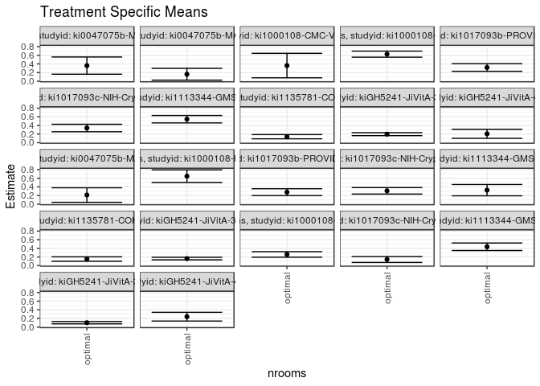

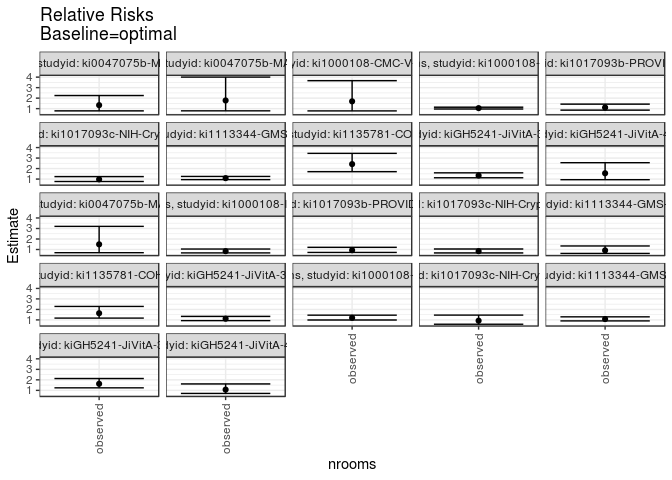

## Results Table

### Parameter: TSM

| agecat | studyid | country | intervention_level | baseline_level | estimate | ci_lower | ci_upper |
| --- | --- | --- | --- | --- | --- | --- | --- |
| 0-24 months | ki0047075b-MAL-ED | INDIA | optimal | NA | 0.3616774 | 0.1624131 | 0.5609417 |
| 0-24 months | ki0047075b-MAL-ED | NEPAL | optimal | NA | 0.1619713 | 0.0248759 | 0.2990666 |
| 0-24 months | ki1000108-CMC-V-BCS-2002 | INDIA | optimal | NA | 0.3622328 | 0.0790528 | 0.6454127 |
| 0-24 months | ki1000108-IRC | INDIA | optimal | NA | 0.6271751 | 0.5571828 | 0.6971673 |
| 0-24 months | ki1017093b-PROVIDE | BANGLADESH | optimal | NA | 0.3178006 | 0.2299233 | 0.4056779 |
| 0-24 months | ki1017093c-NIH-Crypto | BANGLADESH | optimal | NA | 0.3398884 | 0.2532821 | 0.4264946 |
| 0-24 months | ki1113344-GMS-Nepal | NEPAL | optimal | NA | 0.5438862 | 0.4579224 | 0.6298499 |
| 0-24 months | ki1135781-COHORTS | INDIA | optimal | NA | 0.1384455 | 0.0894000 | 0.1874910 |
| 0-24 months | kiGH5241-JiVitA-3 | BANGLADESH | optimal | NA | 0.1975313 | 0.1626836 | 0.2323789 |
| 0-24 months | kiGH5241-JiVitA-4 | BANGLADESH | optimal | NA | 0.2053304 | 0.1007223 | 0.3099386 |
| 0-6 months | ki0047075b-MAL-ED | INDIA | optimal | NA | 0.2112785 | 0.0432115 | 0.3793454 |
| 0-6 months | ki1000108-IRC | INDIA | optimal | NA | 0.6477175 | 0.5016380 | 0.7937970 |
| 0-6 months | ki1017093b-PROVIDE | BANGLADESH | optimal | NA | 0.2777609 | 0.1984085 | 0.3571134 |
| 0-6 months | ki1017093c-NIH-Crypto | BANGLADESH | optimal | NA | 0.3081969 | 0.2333487 | 0.3830451 |
| 0-6 months | ki1113344-GMS-Nepal | NEPAL | optimal | NA | 0.3241433 | 0.1931239 | 0.4551627 |
| 0-6 months | ki1135781-COHORTS | INDIA | optimal | NA | 0.1523967 | 0.1012991 | 0.2034942 |
| 0-6 months | kiGH5241-JiVitA-3 | BANGLADESH | optimal | NA | 0.1633077 | 0.1335871 | 0.1930284 |
| 6-24 months | ki1000108-IRC | INDIA | optimal | NA | 0.2592139 | 0.1954755 | 0.3229524 |
| 6-24 months | ki1017093c-NIH-Crypto | BANGLADESH | optimal | NA | 0.1418460 | 0.0726339 | 0.2110580 |
| 6-24 months | ki1113344-GMS-Nepal | NEPAL | optimal | NA | 0.4367984 | 0.3496474 | 0.5239493 |
| 6-24 months | kiGH5241-JiVitA-3 | BANGLADESH | optimal | NA | 0.1015370 | 0.0741499 | 0.1289242 |
| 6-24 months | kiGH5241-JiVitA-4 | BANGLADESH | optimal | NA | 0.2409153 | 0.1396963 | 0.3421343 |

### Parameter: E(Y)

| agecat | studyid | country | intervention_level | baseline_level | estimate | ci_lower | ci_upper |
| --- | --- | --- | --- | --- | --- | --- | --- |
| 0-24 months | ki0047075b-MAL-ED | INDIA | observed | NA | 0.4808511 | 0.4168346 | 0.5448675 |
| 0-24 months | ki0047075b-MAL-ED | NEPAL | observed | NA | 0.2881356 | 0.2302312 | 0.3460400 |
| 0-24 months | ki1000108-CMC-V-BCS-2002 | INDIA | observed | NA | 0.6139410 | 0.5644682 | 0.6634139 |
| 0-24 months | ki1000108-IRC | INDIA | observed | NA | 0.6568627 | 0.6107393 | 0.7029862 |
| 0-24 months | ki1017093b-PROVIDE | BANGLADESH | observed | NA | 0.3514286 | 0.3160364 | 0.3868207 |
| 0-24 months | ki1017093c-NIH-Crypto | BANGLADESH | observed | NA | 0.3311346 | 0.2976093 | 0.3646598 |
| 0-24 months | ki1113344-GMS-Nepal | NEPAL | observed | NA | 0.5913621 | 0.5520608 | 0.6306634 |
| 0-24 months | ki1135781-COHORTS | INDIA | observed | NA | 0.3354454 | 0.3228114 | 0.3480794 |
| 0-24 months | kiGH5241-JiVitA-3 | BANGLADESH | observed | NA | 0.2642176 | 0.2551208 | 0.2733143 |
| 0-24 months | kiGH5241-JiVitA-4 | BANGLADESH | observed | NA | 0.3184358 | 0.2901120 | 0.3467596 |
| 0-6 months | ki0047075b-MAL-ED | INDIA | observed | NA | 0.3148936 | 0.2553821 | 0.3744051 |
| 0-6 months | ki1000108-IRC | INDIA | observed | NA | 0.5441176 | 0.4957312 | 0.5925041 |
| 0-6 months | ki1017093b-PROVIDE | BANGLADESH | observed | NA | 0.2585714 | 0.2261125 | 0.2910304 |
| 0-6 months | ki1017093c-NIH-Crypto | BANGLADESH | observed | NA | 0.2585752 | 0.2273844 | 0.2897660 |
| 0-6 months | ki1113344-GMS-Nepal | NEPAL | observed | NA | 0.2956811 | 0.2591967 | 0.3321655 |
| 0-6 months | ki1135781-COHORTS | INDIA | observed | NA | 0.2494186 | 0.2376119 | 0.2612253 |
| 0-6 months | kiGH5241-JiVitA-3 | BANGLADESH | observed | NA | 0.1822500 | 0.1742334 | 0.1902667 |
| 6-24 months | ki1000108-IRC | INDIA | observed | NA | 0.3112745 | 0.2662918 | 0.3562572 |
| 6-24 months | ki1017093c-NIH-Crypto | BANGLADESH | observed | NA | 0.1315068 | 0.1069744 | 0.1560393 |
| 6-24 months | ki1113344-GMS-Nepal | NEPAL | observed | NA | 0.4728814 | 0.4325613 | 0.5132014 |
| 6-24 months | kiGH5241-JiVitA-3 | BANGLADESH | observed | NA | 0.1648532 | 0.1556668 | 0.1740396 |
| 6-24 months | kiGH5241-JiVitA-4 | BANGLADESH | observed | NA | 0.2573427 | 0.2311603 | 0.2835250 |

### Parameter: RR

| agecat | studyid | country | intervention_level | baseline_level | estimate | ci_lower | ci_upper |
| --- | --- | --- | --- | --- | --- | --- | --- |
| 0-24 months | ki0047075b-MAL-ED | INDIA | observed | optimal | 1.3295027 | 0.7865054 | 2.247381 |
| 0-24 months | ki0047075b-MAL-ED | NEPAL | observed | optimal | 1.7789303 | 0.7906385 | 4.002579 |
| 0-24 months | ki1000108-CMC-V-BCS-2002 | INDIA | observed | optimal | 1.6948799 | 0.7843324 | 3.662500 |
| 0-24 months | ki1000108-IRC | INDIA | observed | optimal | 1.0473355 | 0.9653751 | 1.136254 |
| 0-24 months | ki1017093b-PROVIDE | BANGLADESH | observed | optimal | 1.1058147 | 0.8566320 | 1.427481 |
| 0-24 months | ki1017093c-NIH-Crypto | BANGLADESH | observed | optimal | 0.9742450 | 0.7690410 | 1.234204 |
| 0-24 months | ki1113344-GMS-Nepal | NEPAL | observed | optimal | 1.0872903 | 0.9452767 | 1.250639 |
| 0-24 months | ki1135781-COHORTS | INDIA | observed | optimal | 2.4229421 | 1.7033422 | 3.446547 |
| 0-24 months | kiGH5241-JiVitA-3 | BANGLADESH | observed | optimal | 1.3375988 | 1.1231127 | 1.593046 |
| 0-24 months | kiGH5241-JiVitA-4 | BANGLADESH | observed | optimal | 1.5508455 | 0.9408380 | 2.556361 |
| 0-6 months | ki0047075b-MAL-ED | INDIA | observed | optimal | 1.4904198 | 0.6938774 | 3.201360 |
| 0-6 months | ki1000108-IRC | INDIA | observed | optimal | 0.8400539 | 0.6768585 | 1.042597 |
| 0-6 months | ki1017093b-PROVIDE | BANGLADESH | observed | optimal | 0.9309136 | 0.7191687 | 1.205002 |
| 0-6 months | ki1017093c-NIH-Crypto | BANGLADESH | observed | optimal | 0.8389936 | 0.6727797 | 1.046272 |
| 0-6 months | ki1113344-GMS-Nepal | NEPAL | observed | optimal | 0.9121924 | 0.6235814 | 1.334381 |
| 0-6 months | ki1135781-COHORTS | INDIA | observed | optimal | 1.6366409 | 1.1729367 | 2.283664 |
| 0-6 months | kiGH5241-JiVitA-3 | BANGLADESH | observed | optimal | 1.1159914 | 0.9323141 | 1.335856 |
| 6-24 months | ki1000108-IRC | INDIA | observed | optimal | 1.2008402 | 0.9932208 | 1.451860 |
| 6-24 months | ki1017093c-NIH-Crypto | BANGLADESH | observed | optimal | 0.9271102 | 0.5884689 | 1.460627 |
| 6-24 months | ki1113344-GMS-Nepal | NEPAL | observed | optimal | 1.0826079 | 0.9068899 | 1.292373 |
| 6-24 months | kiGH5241-JiVitA-3 | BANGLADESH | observed | optimal | 1.6235766 | 1.2407921 | 2.124450 |
| 6-24 months | kiGH5241-JiVitA-4 | BANGLADESH | observed | optimal | 1.0681873 | 0.7085500 | 1.610365 |

### Parameter: PAR

| agecat | studyid | country | intervention_level | baseline_level | estimate | ci_lower | ci_upper |
| --- | --- | --- | --- | --- | --- | --- | --- |
| 0-24 months | ki0047075b-MAL-ED | INDIA | optimal | NA | 0.1191737 | -0.0701935 | 0.3085408 |
| 0-24 months | ki0047075b-MAL-ED | NEPAL | optimal | NA | 0.1261643 | -0.0061916 | 0.2585203 |
| 0-24 months | ki1000108-CMC-V-BCS-2002 | INDIA | optimal | NA | 0.2517083 | -0.0263533 | 0.5297698 |
| 0-24 months | ki1000108-IRC | INDIA | optimal | NA | 0.0296877 | -0.0213009 | 0.0806763 |
| 0-24 months | ki1017093b-PROVIDE | BANGLADESH | optimal | NA | 0.0336280 | -0.0475123 | 0.1147682 |
| 0-24 months | ki1017093c-NIH-Crypto | BANGLADESH | optimal | NA | -0.0087538 | -0.0891252 | 0.0716176 |
| 0-24 months | ki1113344-GMS-Nepal | NEPAL | optimal | NA | 0.0474760 | -0.0285498 | 0.1235018 |
| 0-24 months | ki1135781-COHORTS | INDIA | optimal | NA | 0.1969999 | 0.1476250 | 0.2463748 |
| 0-24 months | kiGH5241-JiVitA-3 | BANGLADESH | optimal | NA | 0.0666863 | 0.0319716 | 0.1014011 |
| 0-24 months | kiGH5241-JiVitA-4 | BANGLADESH | optimal | NA | 0.1131053 | 0.0102016 | 0.2160090 |
| 0-6 months | ki0047075b-MAL-ED | INDIA | optimal | NA | 0.1036152 | -0.0582453 | 0.2654756 |
| 0-6 months | ki1000108-IRC | INDIA | optimal | NA | -0.1035999 | -0.2429237 | 0.0357239 |
| 0-6 months | ki1017093b-PROVIDE | BANGLADESH | optimal | NA | -0.0191895 | -0.0908843 | 0.0525053 |
| 0-6 months | ki1017093c-NIH-Crypto | BANGLADESH | optimal | NA | -0.0496217 | -0.1174448 | 0.0182014 |
| 0-6 months | ki1113344-GMS-Nepal | NEPAL | optimal | NA | -0.0284622 | -0.1519369 | 0.0950124 |
| 0-6 months | ki1135781-COHORTS | INDIA | optimal | NA | 0.0970219 | 0.0459302 | 0.1481137 |
| 0-6 months | kiGH5241-JiVitA-3 | BANGLADESH | optimal | NA | 0.0189423 | -0.0104975 | 0.0483821 |
| 6-24 months | ki1000108-IRC | INDIA | optimal | NA | 0.0520606 | 0.0027668 | 0.1013543 |
| 6-24 months | ki1017093c-NIH-Crypto | BANGLADESH | optimal | NA | -0.0103391 | -0.0748059 | 0.0541277 |
| 6-24 months | ki1113344-GMS-Nepal | NEPAL | optimal | NA | 0.0360830 | -0.0412188 | 0.1133848 |
| 6-24 months | kiGH5241-JiVitA-3 | BANGLADESH | optimal | NA | 0.0633161 | 0.0354798 | 0.0911524 |
| 6-24 months | kiGH5241-JiVitA-4 | BANGLADESH | optimal | NA | 0.0164274 | -0.0825287 | 0.1153834 |

### Parameter: PAF

| agecat | studyid | country | intervention_level | baseline_level | estimate | ci_lower | ci_upper |
| --- | --- | --- | --- | --- | --- | --- | --- |
| 0-24 months | ki0047075b-MAL-ED | INDIA | optimal | NA | 0.2478390 | -0.2714471 | 0.5550376 |
| 0-24 months | ki0047075b-MAL-ED | NEPAL | optimal | NA | 0.4378644 | -0.2648006 | 0.7501611 |
| 0-24 months | ki1000108-CMC-V-BCS-2002 | INDIA | optimal | NA | 0.4099877 | -0.2749696 | 0.7269625 |
| 0-24 months | ki1000108-IRC | INDIA | optimal | NA | 0.0451961 | -0.0358668 | 0.1199154 |
| 0-24 months | ki1017093b-PROVIDE | BANGLADESH | optimal | NA | 0.0956894 | -0.1673624 | 0.2994654 |
| 0-24 months | ki1017093c-NIH-Crypto | BANGLADESH | optimal | NA | -0.0264358 | -0.3003207 | 0.1897610 |
| 0-24 months | ki1113344-GMS-Nepal | NEPAL | optimal | NA | 0.0802824 | -0.0578913 | 0.2004089 |
| 0-24 months | ki1135781-COHORTS | INDIA | optimal | NA | 0.5872786 | 0.4129189 | 0.7098545 |
| 0-24 months | kiGH5241-JiVitA-3 | BANGLADESH | optimal | NA | 0.2523917 | 0.1096174 | 0.3722719 |
| 0-24 months | kiGH5241-JiVitA-4 | BANGLADESH | optimal | NA | 0.3551904 | -0.0628822 | 0.6088189 |
| 0-6 months | ki0047075b-MAL-ED | INDIA | optimal | NA | 0.3290481 | -0.4411768 | 0.6876327 |
| 0-6 months | ki1000108-IRC | INDIA | optimal | NA | -0.1903998 | -0.4774137 | 0.0408566 |
| 0-6 months | ki1017093b-PROVIDE | BANGLADESH | optimal | NA | -0.0742136 | -0.3904943 | 0.1701262 |
| 0-6 months | ki1017093c-NIH-Crypto | BANGLADESH | optimal | NA | -0.1919042 | -0.4863706 | 0.0442251 |
| 0-6 months | ki1113344-GMS-Nepal | NEPAL | optimal | NA | -0.0962599 | -0.6036398 | 0.2505887 |
| 0-6 months | ki1135781-COHORTS | INDIA | optimal | NA | 0.3889924 | 0.1474391 | 0.5621072 |
| 0-6 months | kiGH5241-JiVitA-3 | BANGLADESH | optimal | NA | 0.1039358 | -0.0725999 | 0.2514161 |
| 6-24 months | ki1000108-IRC | INDIA | optimal | NA | 0.1672497 | -0.0068254 | 0.3112281 |
| 6-24 months | ki1017093c-NIH-Crypto | BANGLADESH | optimal | NA | -0.0786205 | -0.6993251 | 0.3153623 |
| 6-24 months | ki1113344-GMS-Nepal | NEPAL | optimal | NA | 0.0763046 | -0.1026696 | 0.2262295 |
| 6-24 months | kiGH5241-JiVitA-3 | BANGLADESH | optimal | NA | 0.3840759 | 0.1940632 | 0.5292900 |
| 6-24 months | kiGH5241-JiVitA-4 | BANGLADESH | optimal | NA | 0.0638346 | -0.4113329 | 0.3790227 |